# Homework #1 Assignment Requirements

The residuals (differences between observed and predicted values) range from a minimum of -39.526 to a maximum of 35.287. The distribution of residuals, with a median close to 0 (0.230), suggests that the model has a reasonable balance of over- and under-predictions. The first quartile (1Q) is -7.712, and the third quartile (3Q) is 8.028, indicating that half of the residuals lie between these values, meaning that most predictions deviate from the actual values by around ±8 units.

Overall, the regression model is statistically significant, but it explains only about 23.58% of the variance in the dependent variable, indicating that other variables not included in the model might be influencing the outcome. Among the predictors, PC2, PC4, PC7, and PC8 show strong significant effects, while PC1 and PC5 are not significant contributors to the model. The residuals appear to be moderately dispersed around the predicted values, and the significant predictors provide meaningful insights into the relationships within the data.

**MODEL 3 Development**

```r
set.seed(123)

# Assuming money_ball_train is your dataset
trainIndex <- createDataPartition(money_ball$TARGET_WINS, p = 0.8,
                                  list = FALSE)
train_data <- money_ball
test_data <- money_ball_eval



control <- trainControl(method = "cv", number = 5)  # 5-fold cross-validation

#Train the model (linear regression in this case)
model3 <- train(TARGET_WINS ~ .,
               data = train_data,
               method = "lm",
               trControl = control)

# Summary of the cross-validation results
print(model3)
```

```
## Linear Regression
##
## 1459 samples
##   16 predictor
##
## No pre-processing
## Resampling: Cross-Validated (5 fold)
## Summary of sample sizes: 1167, 1167, 1167, 1168, 1167
## Resampling results:
##
##   RMSE      Rsquared   MAE
##   9.988737  0.3745199  8.025361
##
## Tuning parameter 'intercept' was held constant at a value of TRUE
```

```r
print(model3$results)
```

```
##   intercept     RMSE  Rsquared      MAE    RMSESD RsquaredSD     MAESD
## 1      TRUE 9.988737 0.3745199 8.025361 0.1646179 0.02405222 0.1387634
```

```r
mse3 <- mean(model3$residuals^2)
r_squared3 <- summary(model3)$r.squared
f_stat3 <- summary(model3)$fstatistic[1]
print(paste("MSE:", mse3, "R-squared:", r_squared3, "F-statistic:", f_stat3))
```

```
## [1] "MSE: NaN R-squared: 0.389740100146236 F-statistic: 57.5579790415471"
```

```r
predictions3 <- predict(model3, newdata = money_ball_eval)
head(predictions3)
```

```
##         1         2         3         4         5         6
## 61.083590 67.678107 72.850636 81.580769 -7.278945  5.905271
```

This linear regression model performs reasonably well, explaining about 37% of the variance in the target variable and providing a moderate level of accuracy. While the error metrics (RMSE, MAE) indicate that the model is making reasonable predictions, the relatively low R-squared suggests that there is room for improvement, possibly by adding more predictors or using more sophisticated models that can capture non-linear patterns.

```r
# Summary of the cross-validation results
model3$resample
```

```
##        RMSE  Rsquared      MAE Resample
## 1  9.836874 0.3888343 7.990879    Fold1
## 2 10.168360 0.3802585 8.215199    Fold2
## 3 10.150719 0.3937132 8.119047    Fold3
## 4  9.960314 0.3332440 7.899124    Fold4
## 5  9.827419 0.3765494 7.902557    Fold5
```

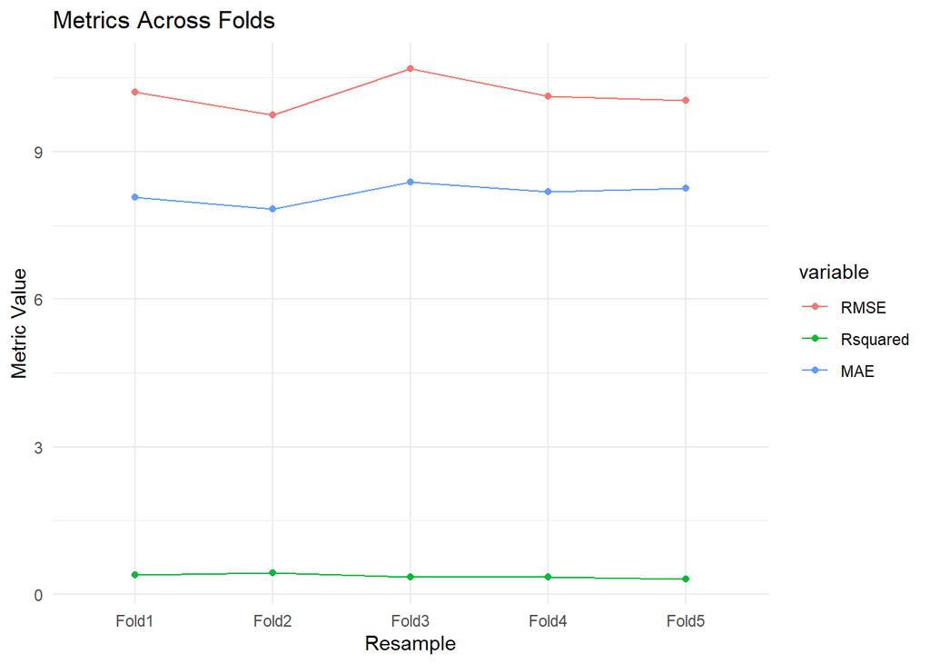

```r
library(ggplot2)
library(reshape2) # for melt function

# Sample data
data <- data.frame(
  RMSE = c(10.211374, 9.748915, 10.693919, 10.120101, 10.037255),
  Rsquared = c(0.3975036, 0.4376530, 0.3577975, 0.3476137, 0.3151282),
  MAE = c(8.068065, 7.832611, 8.377911, 8.179323, 8.261450),
  Resample = c('Fold1', 'Fold2', 'Fold3', 'Fold4', 'Fold5')
)

# Melt data for ggplot
data_melted <- melt(data, id.vars = 'Resample')

# Plot
ggplot(data_melted, aes(x = Resample, y = value, color = variable, group = variable)) +
  geom_line() +
  geom_point() +
  labs(y = "Metric Value", title = "Metrics Across Folds") +
  theme_minimal()
```

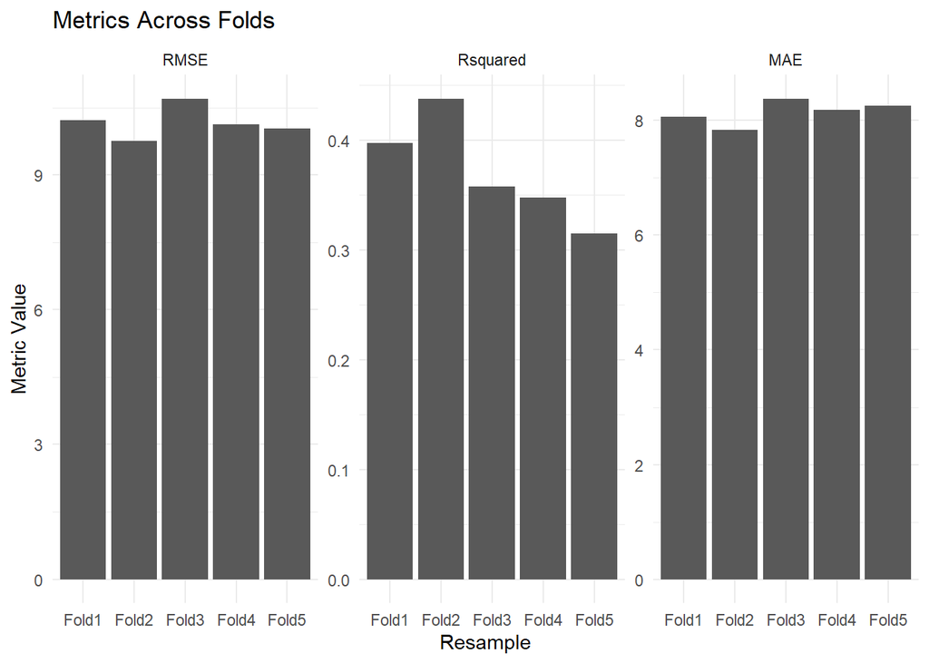

```r
# Faceted plot
ggplot(data_melted, aes(x = Resample, y = value)) +
  geom_bar(stat = 'identity') +
  facet_wrap(~variable, scales = 'free_y') +
  labs(y = "Metric Value", title = "Metrics Across Folds") +
  theme_minimal()
```